# Problemas de clasificación

## Carlos Adrián Palmieri Álvarez

### Ejercicio 1.

### En este ejercicio trabajarás con el conjunto de datos que se te asignó de acuerdo al último número de tu matrícula (ver las notas del ejercicio). En estos archivos se tienen datos procesados de un experimento de psicología en el que se mide la respuesta cerebral cuando un sujeto presta atención a un estímulo visual que aparece de manera repentina y cuando no presta atención a dicho estímulo visual. Los datos están en archivos de texto, los cuales se cargan con la función loadtxt de numpyLinks to an external site.. La primera columna corresponde a la clase (1 o 2). La clase 1 representa cuando el sujeto está prestando atención, y la clase 2 cuando no lo hace. La segunda columna se ignora, mientras que el resto de las columnas indican las variables que se calcularon de la respuesta cerebral medida con la técnicas de Electroencefaolografía para cada caso.

Importaciones

```python
import numpy as np
import pandas as pd
import matplotlib.pyplot as plt
from pprint import pprint
from IPython.display import clear_output
import os
import random

from sklearn.model_selection import train_test_split, cross_val_score, KFold, GridSearchCV
from sklearn.metrics import make_scorer, f1_score, classification_report, confusion_matrix
from sklearn.preprocessing import StandardScaler
from sklearn.feature_selection import SelectKBest, f_classif, RFE, RFECV
from sklearn.linear_model import LogisticRegression
from sklearn.tree import DecisionTreeClassifier
from sklearn.ensemble import RandomForestClassifier, GradientBoostingClassifier, AdaBoostClassifier
from sklearn.svm import SVC
from sklearn.neighbors import KNeighborsClassifier
from sklearn.naive_bayes import GaussianNB

from imblearn.pipeline import Pipeline as ImbPipeline
from imblearn.under_sampling import RandomUnderSampler
```

```python
# Cargamos los datos del archivo de texto, la segunda columna se ignorará

datos = np.loadtxt('../data/raw/P1_4.txt')
df = pd.DataFrame(datos)
df = df.drop(columns=[1])
df.rename(columns={0: 'atencion'}, inplace=True)

# Si encuentra un valor 2 en la columna atencion, lo cambia por 0
df['atencion'] = df['atencion'].replace(2, 0)
df
```

|  | atencion | 2 | 3 | 4 | 5 | 6 | 7 | 8 | 9 | 10 | ... | 145 | 146 | 147 | 148 | 149 | 150 | 151 | 152 | 153 | 154 |
| --- | --- | --- | --- | --- | --- | --- | --- | --- | --- | --- | --- | --- | --- | --- | --- | --- | --- | --- | --- | --- | --- |
| 0 | 1.0 | 0.350647 | -0.424993 | -0.660866 | -0.815144 | -1.241745 | -1.665021 | -1.618643 | -1.196400 | -1.047875 | ... | -1.251889 | -1.970338 | -2.506193 | -2.352022 | -1.766605 | -1.276660 | -0.914575 | -0.319748 | 0.595015 | 1.473851 |
| 1 | 1.0 | 1.580375 | 1.176607 | -0.191975 | -0.932377 | -0.439725 | 0.438743 | 0.719484 | 0.432720 | 0.185609 | ... | -0.523751 | 0.549496 | 1.015399 | 0.906942 | 0.703602 | 0.556465 | 0.303205 | 0.051880 | 0.104996 | 0.324812 |
| 2 | 1.0 | -0.316008 | 1.056184 | 2.025188 | 2.206168 | 2.072054 | 2.076986 | 2.022388 | 1.503590 | 0.621748 | ... | -1.121012 | -1.051379 | -0.297674 | 0.353843 | 0.345961 | 0.195128 | 0.642133 | 1.445067 | 1.671265 | 1.014228 |
| 3 | 1.0 | -1.093552 | -0.910001 | -1.003384 | -1.055967 | -0.878846 | -0.658754 | -0.426029 | 0.158841 | 1.106279 | ... | -0.196825 | -0.832196 | -0.943520 | -0.431187 | 0.066089 | -0.036773 | -0.618627 | -1.023145 | -0.716475 | 0.219482 |
| 4 | 1.0 | -0.146399 | -0.110799 | 0.455934 | 0.876946 | 0.684550 | 0.132343 | -0.305652 | -0.535346 | -0.711652 | ... | -1.223037 | -1.154985 | -0.900329 | -0.697651 | -0.769296 | -0.932597 | -0.743404 | -0.096057 | 0.582817 | 0.885652 |
| ... | ... | ... | ... | ... | ... | ... | ... | ... | ... | ... | ... | ... | ... | ... | ... | ... | ... | ... | ... | ... | ... |
| 1189 | 0.0 | -1.588847 | -1.427003 | -0.269426 | 0.696609 | 0.623781 | -0.030702 | -0.452824 | -0.661629 | -1.124753 | ... | 0.667013 | 0.938670 | 0.973536 | 0.856223 | 0.744666 | 0.586719 | 0.334001 | 0.207453 | 0.410789 | 0.637030 |
| 1190 | 0.0 | 0.786812 | 0.614816 | 0.097663 | -0.675592 | -0.914119 | -0.122366 | 0.934836 | 0.969639 | -0.150785 | ... | 0.942854 | 1.317201 | 1.396222 | 1.146528 | 0.732923 | 0.260424 | -0.135460 | -0.194619 | 0.110225 | 0.290046 |
| 1191 | 0.0 | 0.835499 | 0.217704 | -0.026337 | -0.081543 | -0.149609 | -0.142239 | -0.030333 | -0.043847 | -0.277810 | ... | 0.581388 | 0.970642 | 1.261227 | 1.389007 | 1.349219 | 1.032691 | 0.288468 | -0.694130 | -1.330831 | -1.242224 |
| 1192 | 0.0 | -1.002186 | -1.447046 | -1.189321 | -0.399778 | 0.305956 | 0.485641 | 0.154627 | -0.328849 | -0.539770 | ... | 0.770430 | 1.359351 | 1.057704 | 0.161317 | -0.361443 | -0.196288 | 0.031061 | -0.228708 | -0.750366 | -1.008360 |
| 1193 | 0.0 | -2.254510 | -1.340262 | -0.078634 | 0.815721 | 1.069722 | 1.032260 | 1.087142 | 1.199964 | 1.101077 | ... | 0.834686 | 0.276603 | 0.111606 | 0.127566 | 0.113644 | 0.198501 | 0.405971 | 0.381965 | -0.019670 | -0.255823 |

1194 rows × 154 columns

#### 1. Determina si es necesario balancear los datos. En caso de que sea afirmativo, en todo este ejercicio tendrás que utilizar alguna estrategia para mitigar el problema de tener una muestra desbalanceada.

```
atencion
0.0    895
1.0    299
Name: count, dtype: int64
```

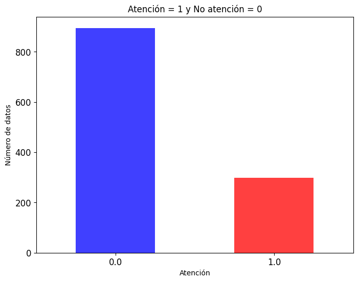

```python
# Determinamos el número de datos para cuando atencion = 1 y atencion = 2
atencion = df['atencion'].value_counts()
print(atencion)

# Gradica de barras
df['atencion'].value_counts().plot(kind='bar', color=['blue', 'red'], alpha=0.75, rot=0, figsize=(8, 6), fontsize=12)
# Añadimos título y etiquetas
plt.title('Atención = 1 y No atención = 0')
plt.xlabel('Atención')
plt.ylabel('Número de datos')
plt.show()
```

```python
# Función para balancear los datos por medio de la técnica de submuestreo
def submuestreodf(df):
    # Contamos el número de datos para cada clase
    atencion = df['atencion'].value_counts()
    # Seleccionamos el número de datos de la clase mayoritaria
    if atencion[0] > atencion[1]:
        clase_mayoritaria = df[df['atencion'] == 0]
        clase_minoritaria = df[df['atencion'] == 1]
    else:
        clase_mayoritaria = df[df['atencion'] == 1]
        clase_minoritaria = df[df['atencion'] == 0]
    # Borramos aleatoriamente datos de la clase mayoritaria para igualar el número de datos a la clase minoritaria
    clase_mayoritaria = clase_mayoritaria.sample(len(clase_minoritaria), random_state=0)
    df = pd.concat([clase_mayoritaria, clase_minoritaria])
    return df
```

```
atencion
0.0    299
1.0    299
Name: count, dtype: int64
```

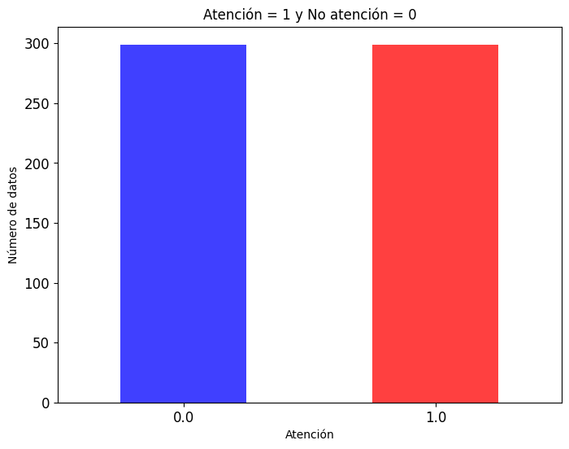

```python
df_sub = submuestreodf(df)
print(df_sub['atencion'].value_counts())

# Gradica de barras
df_sub['atencion'].value_counts().plot(kind='bar', color=['blue', 'red'], alpha=0.75, rot=0, figsize=(8, 6), fontsize=12)
# Añadimos título y etiquetas
plt.title('Atención = 1 y No atención = 0')
plt.xlabel('Atención')
plt.ylabel('Número de datos')
plt.show()
```

```python
df_sub
```

|  | atencion | 2 | 3 | 4 | 5 | 6 | 7 | 8 | 9 | 10 | ... | 145 | 146 | 147 | 148 | 149 | 150 | 151 | 152 | 153 | 154 |
| --- | --- | --- | --- | --- | --- | --- | --- | --- | --- | --- | --- | --- | --- | --- | --- | --- | --- | --- | --- | --- | --- |
| 845 | 0.0 | 1.756614 | 0.970539 | -0.394123 | -1.054680 | -0.686820 | 0.260546 | 1.309863 | 2.043689 | 1.987294 | ... | 0.467778 | 0.479558 | 0.557632 | 0.744180 | 0.927159 | 0.830450 | 0.375080 | -0.117192 | -0.293080 | -0.252848 |
| 495 | 0.0 | 0.586218 | 0.966244 | 0.110159 | -1.239295 | -1.453078 | 0.011467 | 1.964509 | 2.805271 | 2.045401 | ... | 0.841063 | 0.903567 | 0.970041 | 1.102468 | 1.143662 | 0.866735 | 0.295644 | -0.243043 | -0.425464 | -0.180734 |
| 702 | 0.0 | -0.385092 | -0.800838 | -0.877645 | -0.720395 | -0.729744 | -0.770475 | -0.388100 | 0.215511 | 0.243608 | ... | -0.926273 | -0.969597 | -0.405447 | -0.160183 | -0.787313 | -1.650056 | -1.761880 | -1.092829 | -0.492048 | -0.440842 |
| 330 | 0.0 | -1.757793 | -1.563055 | -0.680732 | 0.096407 | 0.040984 | -0.403087 | -0.229756 | 0.761441 | 1.740595 | ... | -0.625401 | 0.165404 | 0.502685 | -0.012996 | -0.784124 | -1.036812 | -0.743912 | -0.456334 | -0.431166 | -0.404853 |
| 1124 | 0.0 | -0.765344 | -0.770750 | -0.516638 | 0.211623 | 1.303581 | 2.334969 | 2.805250 | 2.516882 | 1.761034 | ... | 0.124852 | 0.210310 | -0.241771 | -0.555366 | -0.250509 | 0.259859 | 0.290236 | -0.063863 | -0.025088 | 0.689206 |
| ... | ... | ... | ... | ... | ... | ... | ... | ... | ... | ... | ... | ... | ... | ... | ... | ... | ... | ... | ... | ... | ... |
| 294 | 1.0 | 0.056560 | 0.137288 | 0.549970 | 1.217710 | 1.434545 | 0.938932 | 0.350281 | 0.169870 | -0.023839 | ... | 0.423394 | 0.499334 | -0.336806 | -1.235325 | -1.224719 | -0.314852 | 0.599542 | 0.825440 | 0.560266 | 0.434820 |
| 295 | 1.0 | 0.066216 | 0.202585 | 0.641107 | 1.024390 | 1.126217 | 1.014071 | 0.877950 | 0.732590 | 0.442525 | ... | -0.348810 | -0.352680 | -0.105089 | 0.104837 | 0.002273 | -0.289964 | -0.497940 | -0.517355 | -0.287530 | 0.268509 |
| 296 | 1.0 | -0.277810 | -0.424327 | -0.213445 | 0.078530 | -0.067988 | -0.630677 | -0.979669 | -0.730933 | -0.312380 | ... | -1.330831 | -1.242224 | -0.699282 | -0.193759 | 0.194083 | 0.615747 | 0.879366 | 0.636321 | 0.123151 | 0.094425 |
| 297 | 1.0 | 0.153037 | 0.385719 | 0.263618 | 0.122113 | 0.313857 | 0.698718 | 0.834000 | 0.645090 | 0.556694 | ... | -0.830742 | -0.313315 | 0.452383 | 1.187760 | 1.288005 | 0.420496 | -0.840868 | -1.470708 | -1.142315 | -0.549211 |
| 298 | 1.0 | -0.124130 | -0.791487 | -1.198658 | -1.357572 | -1.289140 | -0.733794 | 0.311895 | 1.153722 | 1.085193 | ... | -1.647987 | -1.480157 | -0.552161 | 0.233541 | 0.525887 | 0.865178 | 1.612607 | 2.259480 | 2.230701 | 1.839256 |

598 rows × 154 columns

#### 2. Evalúa al menos 8 modelos de clasificación distintos utilizando validación cruzada, y determina cuál de ellos es el más efectivo.

##### Función de submuestreo recibiendo parametro X y parametro y.

```python
def submuestreo(X, y):
    df = pd.DataFrame(X)
    df['atencion'] = y
    atencion = df['atencion'].value_counts()
    if atencion[0] > atencion[1]:
        clase_mayoritaria = df[df['atencion'] == 0]
        clase_minoritaria = df[df['atencion'] == 1]
    else:
        clase_mayoritaria = df[df['atencion'] == 1]
        clase_minoritaria = df[df['atencion'] == 0]
    clase_mayoritaria = clase_mayoritaria.sample(len(clase_minoritaria), random_state=0)
    df = pd.concat([clase_mayoritaria, clase_minoritaria])
    X_resampled = df.drop(columns=['atencion'])
    y_resampled = df['atencion']
    return X_resampled, y_resampled
```

##### Función para evaluar modelos

(Evalua modelos de clasificación con submuestreo para conjunto de entrenamiento, validación cruzada e impresión de matríz de confusión.)

```python
def evaluate_model(model, X_train, y_train, X_test, y_test):
    # Submuestreo en el conjunto de entrenamiento
    X_train_resampled, y_train_resampled = submuestreo(X_train, y_train)
    #print(X_train_resampled.value_counts())
    #print(y_train_resampled.value_counts())

    pipeline = ImbPipeline(steps=[
        ('scaler', StandardScaler()),
        ('classifier', model)
    ])

    # Validación cruzada en el conjunto de entrenamiento
    scores = cross_val_score(pipeline, X_train_resampled, y_train_resampled, cv=5, scoring='f1')
    print(f'F1 Score: {scores.mean():.4f}')

    # Ajuste del modelo
    pipeline.fit(X_train_resampled, y_train_resampled)
    y_pred = pipeline.predict(X_test)
    print(classification_report(y_test, y_pred))

    # Matriz de confusión
    cm = confusion_matrix(y_test, y_pred)

    fig, ax = plt.subplots()
    im = ax.imshow(cm, interpolation='nearest', cmap=plt.cm.Blues)
    ax.figure.colorbar(im, ax=ax)
    # Mostramos las etiquetas
    ax.set(xticks=np.arange(cm.shape[1]),
           yticks=np.arange(cm.shape[0]),
           xticklabels=['No atención', 'Atención'], yticklabels=['No atención', 'Atención'],
           title='Matriz de confusión',
           ylabel='Etiqueta verdadera',
           xlabel='Etiqueta predicha')
    plt.setp(ax.get_xticklabels(), rotation=45, ha='right', rotation_mode='anchor')

    for i in range(cm.shape[0]):
        for j in range(cm.shape[1]):
            ax.text(j, i, format(cm[i, j], 'd'), ha='center', va='center', color='black')
    fig.tight_layout()
    plt.show()

    return scores.mean()
```

##### Separando df = Xtrain, Xtest. ytrain, ytest.

```python
X = df.drop(columns=['atencion'])
y = df['atencion']
X_train, X_test, y_train, y_test = train_test_split(X, y, test_size=0.3, random_state=42)
```

##### Regresión logística (Modelo lineal lógico)

```
-------- Evaluando Regresión Logística --------
F1 Score: 0.9157
              precision    recall  f1-score   support

         0.0       0.96      0.92      0.94       266
         1.0       0.79      0.89      0.84        93

    accuracy                           0.91       359
   macro avg       0.88      0.90      0.89       359
weighted avg       0.92      0.91      0.91       359
```

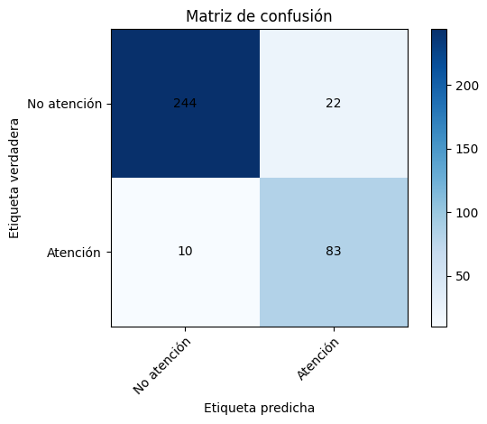

```
np.float64(0.9156611177700948)
```

```python
# Regresión logística
print('-------- Evaluando Regresión Logística --------')
evaluate_model(LogisticRegression(), X_train, y_train, X_test, y_test)
```

##### Árbol de decisión (Modelo no-lineal lógico)

```
-------- Evaluando Árbol de Decisión --------
F1 Score: 0.8205
              precision    recall  f1-score   support

         0.0       0.92      0.86      0.89       266
         1.0       0.66      0.78      0.72        93

    accuracy                           0.84       359
   macro avg       0.79      0.82      0.80       359
weighted avg       0.85      0.84      0.84       359
```

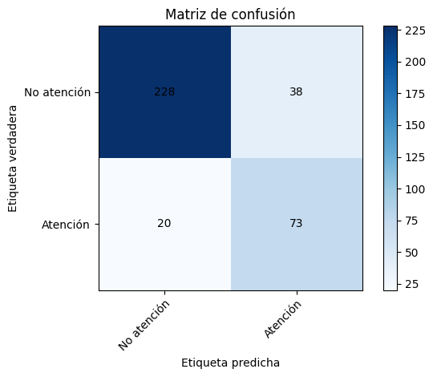

```
np.float64(0.8205235656759733)
```

```python
# Arbol de decisión
print('-------- Evaluando Árbol de Decisión --------')
evaluate_model(DecisionTreeClassifier(), X_train, y_train, X_test, y_test)
```

##### Random Forest (Modelo no-lineal ensamble)

```
-------- Evaluando Random Forest --------
F1 Score: 0.9213
              precision    recall  f1-score   support

         0.0       0.97      0.96      0.97       266
         1.0       0.89      0.92      0.91        93

    accuracy                           0.95       359
   macro avg       0.93      0.94      0.94       359
weighted avg       0.95      0.95      0.95       359
```

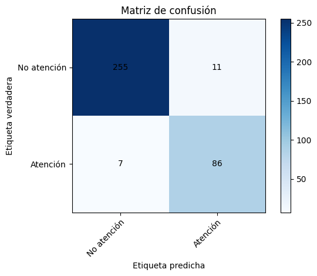

```
np.float64(0.9213039895966725)
```

```python
# Random Forest
print('-------- Evaluando Random Forest --------')
evaluate_model(RandomForestClassifier(), X_train, y_train, X_test, y_test)
```

##### Support Vector Machine (Modelo no-lineal(kernel=rbf) geométrico)

```
-------- Evaluando SVM --------
F1 Score: 0.9364
              precision    recall  f1-score   support

         0.0       0.97      0.95      0.96       266
         1.0       0.86      0.91      0.89        93

    accuracy                           0.94       359
   macro avg       0.91      0.93      0.92       359
weighted avg       0.94      0.94      0.94       359
```

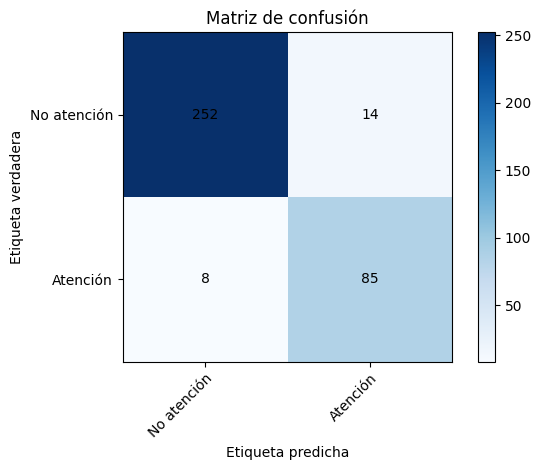

```
np.float64(0.9364055316287775)
```

```python
# SVM
print('-------- Evaluando SVM --------')
evaluate_model(SVC(kernel='rbf'), X_train, y_train, X_test, y_test)
```

##### Gradient Boosting (Modelo no-lineal ensamble)

```
-------- Evaluando Gradient Boosting --------
F1 Score: 0.8991
              precision    recall  f1-score   support

         0.0       0.96      0.94      0.95       266
         1.0       0.84      0.88      0.86        93

    accuracy                           0.92       359
   macro avg       0.90      0.91      0.90       359
weighted avg       0.93      0.92      0.93       359
```

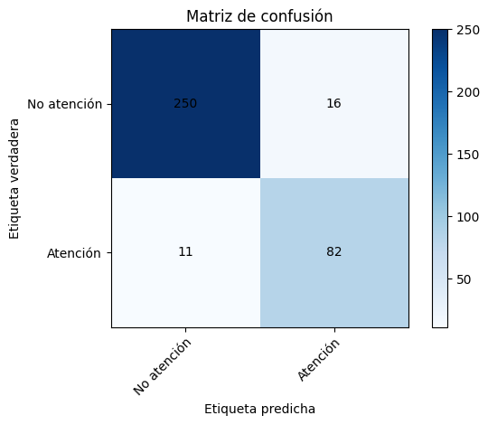

```
np.float64(0.8991064315331782)
```

```python
# Gradient Boosting
print('-------- Evaluando Gradient Boosting --------')
evaluate_model(GradientBoostingClassifier(), X_train, y_train, X_test, y_test)
```

##### K-vecinos más cercanos (Modelo no-lineal geométrico)

```
-------- Evaluando KNN --------
```

[output not shown]

```
F1 Score: 0.9272
              precision    recall  f1-score   support

         0.0       0.98      0.88      0.93       266
         1.0       0.74      0.95      0.83        93

    accuracy                           0.90       359
   macro avg       0.86      0.91      0.88       359
weighted avg       0.92      0.90      0.90       359
```

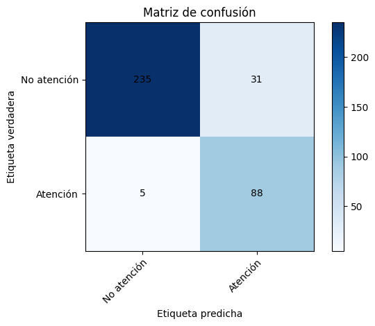

```
np.float64(0.9272099954270459)
```

```python
# KNN
print('-------- Evaluando KNN --------')
evaluate_model(KNeighborsClassifier(), X_train, y_train, X_test, y_test)
```

##### Naive Bayes (Modelo lineal probabilistico)

```
-------- Evaluando Naive Bayes --------
F1 Score: 0.9275
              precision    recall  f1-score   support

         0.0       0.98      0.94      0.96       266
         1.0       0.85      0.94      0.89        93

    accuracy                           0.94       359
   macro avg       0.91      0.94      0.93       359
weighted avg       0.94      0.94      0.94       359
```

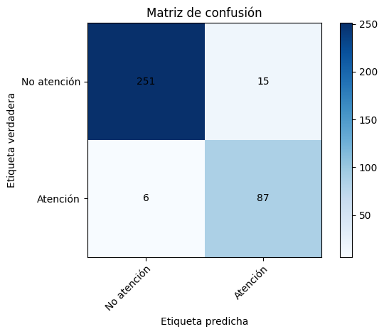

```
np.float64(0.9274908419206541)
```

```python
# Naive Bayes
print('-------- Evaluando Naive Bayes --------')
evaluate_model(GaussianNB(), X_train, y_train, X_test, y_test)
```

##### Adaboost (Modelo no-lineal ensabamble(lógico))

```
-------- Evaluando AdaBoost --------
F1 Score: 0.9041
              precision    recall  f1-score   support

         0.0       0.98      0.93      0.95       266
         1.0       0.83      0.94      0.88        93

    accuracy                           0.93       359
   macro avg       0.90      0.93      0.92       359
weighted avg       0.94      0.93      0.93       359
```

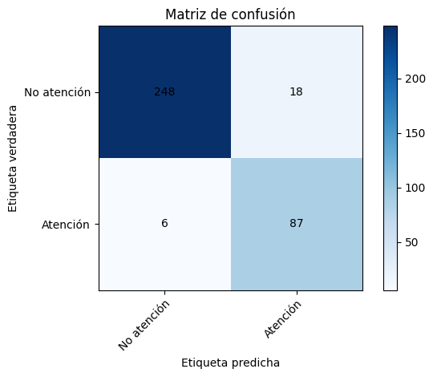

```
np.float64(0.9040799462996475)
```

```python
# AdaBoost
print('-------- Evaluando AdaBoost --------')
evaluate_model(AdaBoostClassifier(algorithm='SAMME'), X_train, y_train, X_test, y_test)
```

```
El mejor modelo es SVM con un F1 Score de 0.9364
F1 Score: 0.9041
              precision    recall  f1-score   support

         0.0       0.98      0.93      0.95       266
         1.0       0.83      0.94      0.88        93

    accuracy                           0.93       359
   macro avg       0.90      0.93      0.92       359
weighted avg       0.94      0.93      0.93       359
```

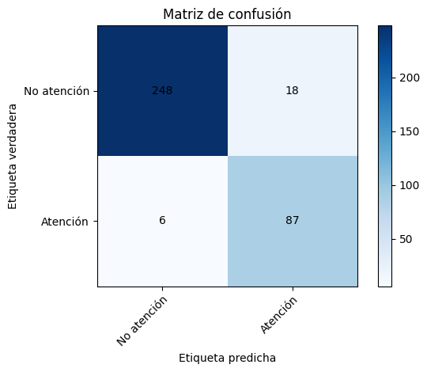

```
np.float64(0.9040799462996475)
```

```python
# Corriendo de nuevo todos los datos pero comparando cuál es el mejor modelo según el F1 Score
models = {
    'Regresión Logística': LogisticRegression(),
    'Árbol de Decisión': DecisionTreeClassifier(),
    'Random Forest': RandomForestClassifier(),
    'SVM': SVC(kernel='rbf'),
    'Gradient Boosting': GradientBoostingClassifier(),
    'KNN': KNeighborsClassifier(),
    'Naive Bayes': GaussianNB(),
    'AdaBoost': AdaBoostClassifier(algorithm='SAMME')
}

f_scores = {}

for name, model in models.items():
    print(f'-------- Evaluando {name} --------')
    f_score = evaluate_model(model, X_train, y_train, X_test, y_test)
    f_scores[name] = f_score

    clear_output(wait=True)
    os.system('clear')

best_model = max(f_scores, key=f_scores.get)
clear_output(wait=True)
os.system('clear')
print(f'El mejor modelo es {best_model} con un F1 Score de {f_scores[best_model]:.4f}')
evaluate_model(model, X_train, y_train, X_test, y_test)
```

#### 3. Implementa desde cero el método de regresión logística, y evalúalo con el conjunto de datos.

```python
def sigmoide(x):
    return 1 / (1 + np.exp(-x))
```

```python
# Gradient error function
def grad_logistic(X, y, w):
    n_samples = X.shape[0]
    n_features = X.shape[1]

    # Calculo de gradiente
    grad = np.zeros(n_features)
    for i in range(n_samples):
        grad += (sigmoide(np.dot(w, X[i])) - y[i]) * X[i]
    grad /= n_samples

    return grad
```

```python
def predict(X, w):
    return sigmoide(np.dot(X, w))
```

```python
# Regresión logística sin librerías
def fit_model(X, y, alpha=0.001, maxiter=1000):
    n_samples = X.shape[0]
    n_features = X.shape[1]
    w = np.zeros(n_features)

    for _ in range(maxiter):
        w -= alpha * grad_logistic(X, y, w)

    return w
```

```
F1 Score: 0.7565
              precision    recall  f1-score   support

         0.0       1.00      0.78      0.88       171
         1.0       0.64      1.00      0.78        67

    accuracy                           0.84       238
   macro avg       0.82      0.89      0.83       238
weighted avg       0.90      0.84      0.85       238
```

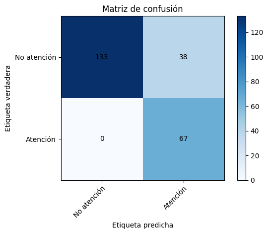

```python
#Evaluando con CV Kfold
from sklearn.model_selection import KFold
from sklearn.metrics import f1_score, classification_report, confusion_matrix
import random

n_folds = 5
kf = KFold(n_splits=n_folds, shuffle=True, random_state=0)

f_scores = []
for train_index, test_index in kf.split(X):
    X_train, X_test = X.values[train_index], X.values[test_index]
    y_train, y_test = y.values[train_index], y.values[test_index]

    x1 = X_train[y_train == 1, :]
    y1 = y_train[y_train == 1]
    n1 = len(y1)

    x2 = X_train[y_train == 0, :]
    y2 = y_train[y_train == 0]
    n2 = len(y2)

    if n1 > n2:
        x1, x2 = x2, x1
        y1, y2 = y2, y1
        n1, n2 = n2, n1
    # Submuestreo
    ind = random.sample(range(n2), n1)

    x_sub = np.concatenate((x1, x2[ind, :]), axis=0)
    y_sub = np.concatenate((y1, y2[ind]), axis=0)


    # Ajuste del modelo
    w = fit_model(x_sub, y_sub)
    y_pred = predict(X_test, w)
    y_pred = (y_pred > 0.5).astype(int)

    f_scores.append(f1_score(y_test, y_pred))


print(f'F1 Score: {np.mean(f_scores):.4f}')
print(classification_report(y_test, y_pred))
cm = confusion_matrix(y_test, y_pred)

fig, ax = plt.subplots()
im = ax.imshow(cm, interpolation='nearest', cmap=plt.cm.Blues)
ax.figure.colorbar(im, ax=ax)

ax.set(xticks=np.arange(cm.shape[1]),
       yticks=np.arange(cm.shape[0]),
       xticklabels=['No atención', 'Atención'], yticklabels=['No atención', 'Atención'],
       title='Matriz de confusión',
       ylabel='Etiqueta verdadera',
       xlabel='Etiqueta predicha')
plt.setp(ax.get_xticklabels(), rotation=45, ha='right', rotation_mode='anchor')

for i in range(cm.shape[0]):
    for j in range(cm.shape[1]):
        ax.text(j, i, format(cm[i, j], 'd'), ha='center', va='center', color='black')
fig.tight_layout()
plt.show()
```

#### 4. Con alguno de los clasificadores que probaste en los pasos anteriores, determina el número óptimo de características utilizando un método tipo Filter.

##### Probando el modelo SVC (rbf) y RandomForestClassifier

```python
# submuestreo, validación cruzada y selección de características
def evaluate_model_fs(model, X_train, y_train, X_test, y_test, feature_selector_method, param_values=None):
    if feature_selector_method == 'filter':
        param_values = {'feature_selection__k': [5, 10, 20, 30, 40, 50],
                        'classifier__C': [0.1, 1, 10],
                        'classifier__gamma': [0.001, 0.01, 0.1, 1, 10]}
    elif feature_selector_method == 'wrapper':
        param_values = {'feature_selection__n_features_to_select': [5, 10, 40, 50]}
    elif feature_selector_method == 'recursivo':
        param_values = {'feature_selection__step': [40, 60, 80, 100]}
    else:
        raise ValueError(f"Método de selección de características '{feature_selector_method}' no reconocido")

    # Definir la validación cruzada externa
    outer_kf = KFold(n_splits=5, shuffle=True, random_state=0)
    fold_scores = []
    f1_scores = []
    f0_scores = []

    for outer_train_index, outer_test_index in outer_kf.split(X):
        # Si X es un DataFrame
        X_train, X_test = X.iloc[outer_train_index], X.iloc[outer_test_index]
        y_train, y_test = y.iloc[outer_train_index], y.iloc[outer_test_index]

        # Submuestreo en el conjunto de entrenamiento externo
        X_train_resampled, y_train_resampled = submuestreo(X_train, y_train)

        # Definir la validación cruzada interna
        inner_kf = KFold(n_splits=5, shuffle=True, random_state=0)

        # Selección de características basada en el método proporcionado
        if feature_selector_method == 'filter':
            feature_selector = SelectKBest(f_classif)
        elif feature_selector_method == 'wrapper':
            feature_selector = RFE(estimator=RandomForestClassifier())
        elif feature_selector_method == 'recursivo':
            feature_selector = RFECV(estimator=RandomForestClassifier(), step=1, cv=inner_kf, scoring='f1')
        else:
            raise ValueError(f"Método de selección de características '{feature_selector_method}' no reconocido")

        # Crear el pipeline con selección de características y clasificación
        pipeline = ImbPipeline(steps=[
            ('scaler', StandardScaler()),
            ('feature_selection', feature_selector),
            ('classifier', model)
        ])

        # Configurar la búsqueda de hiperparámetros en la validación cruzada interna
        grid_search = GridSearchCV(pipeline, param_values, cv=inner_kf, scoring='f1', n_jobs=-1)

        # Ajustar la búsqueda de hiperparámetros
        grid_search.fit(X_train_resampled, y_train_resampled)

        # Obtener el mejor pipeline con los hiperparámetros óptimos
        best_pipeline = grid_search.best_estimator_

        # Evaluar el mejor pipeline en el conjunto de prueba interno
        y_pred = best_pipeline.predict(X_test)

        f1 = classification_report(y_test, y_pred, output_dict=True)
        fold_scores.append(f1)
        #print(f1)



        # Imprimir características seleccionadas
        feature_selector = best_pipeline.named_steps['feature_selection']
        selected_features = X_train.columns[feature_selector.get_support()]

        if feature_selector_method == 'filter':
            print(f'\nParticion numero {len(fold_scores)}: Características seleccionadas (Filtro): {selected_features}')
        elif feature_selector_method == 'wrapper':
            print(f'\nPaticion numero {len(fold_scores)}: Características seleccionadas (Wrapper): {selected_features}')
        elif feature_selector_method == 'recursivo':
            print(f'\nPaticion numero {len(fold_scores)}: Características seleccionadas (Recursivo): {selected_features}')

        for key, values in f1.items():
            if key == '1.0':
                print(f'f-score para la clase 1 {values["f1-score"]}')
                f1_scores.append(values["f1-score"])
            elif key == '0.0':
                print(f'f-score para la clase 0 {values["f1-score"]}')
                f0_scores.append(values["f1-score"])

        #pprint(f1)
    print (f'\n\tf1-score promedio para la clase 1: {np.mean(f1_scores)}')
    print (f'\n\tf1-score promedio para la clase 0: {np.mean(f0_scores)}')
```

##### Método filter

```python
# SVC con kernel rbf metodo filter
print('-------- Evaluando SVM --------')
evaluate_model_fs(SVC(kernel='rbf'), X_train, y_train, X_test, y_test, 'filter', param_values=None)
```

```
-------- Evaluando SVM --------

Particion numero 1: Características seleccionadas (Filtro): Index([  3,  12,  13,  14,  18,  19,  20,  21,  22,  24,  25,  26,  27,  28,
        29,  30,  31,  32,  64,  65,  67,  68,  69,  75,  81,  82,  83,  84,
        92,  93,  94,  95, 121, 137, 138, 139, 140, 141, 142, 143],
      dtype='object')
f-score para la clase 0 0.9529085872576177
f-score para la clase 1 0.8547008547008547

Particion numero 2: Características seleccionadas (Filtro): Index([ 13,  18,  19,  20,  21,  22,  25,  26,  27,  28,  29,  30,  31,  32,
        68,  83,  84, 139, 140, 141],
      dtype='object')
f-score para la clase 0 0.9411764705882353
f-score para la clase 1 0.8264462809917356

Particion numero 3: Características seleccionadas (Filtro): Index([ 12,  13,  14,  18,  19,  20,  21,  22,  25,  26,  27,  28,  29,  30,
        31,  32,  36,  68,  69,  75,  76,  77,  82,  83,  84, 138, 140, 141,
       142, 143],
      dtype='object')
f-score para la clase 0 0.9507246376811594
f-score para la clase 1 0.8721804511278195

Particion numero 4: Características seleccionadas (Filtro): Index([  3,  12,  13,  14,  18,  19,  20,  21,  22,  24,  25,  26,  27,  28,
        29,  30,  31,  32,  35,  36,  64,  65,  67,  68,  69,  70,  75,  76,
        77,  82,  83,  84,  85,  89,  90,  91,  92,  93,  94, 121, 122, 127,
       128, 137, 138, 139, 140, 141, 142, 143],
      dtype='object')
f-score para la clase 0 0.9529085872576177
f-score para la clase 1 0.8547008547008547

Particion numero 5: Características seleccionadas (Filtro): Index([  2,   3,  12,  13,  14,  18,  19,  20,  21,  22,  24,  25,  26,  27,
        28,  29,  30,  31,  32,  35,  36,  64,  65,  67,  68,  69,  70,  75,
        76,  77,  81,  82,  83,  84,  85,  90,  91,  92,  93,  94,  95, 137,
       138, 139, 140, 141, 142, 143, 153, 154],
      dtype='object')
f-score para la clase 0 0.926829268292683
f-score para la clase 1 0.8378378378378378

	f1-score promedio para la clase 1: 0.8491732558718205

	f1-score promedio para la clase 0: 0.9449095102154625
```

#### 5. Repite el paso anterior, pero para un método de selección de características secuencial.

##### Método Wrapper

```python
# RFC metodo wrapper
print('-------- Evaluando RFC --------')
evaluate_model_fs(RandomForestClassifier(), X_train, y_train, X_test, y_test, 'wrapper', param_values=None)
```

```
-------- Evaluando RFC --------

Paticion numero 1: Características seleccionadas (Wrapper): Index([  6,  10,  12,  13,  14,  18,  19,  20,  21,  22,  23,  24,  25,  26,
        27,  28,  29,  30,  31,  35,  36,  37,  40,  45,  63,  64,  65,  67,
        68,  69,  75,  76,  82,  83,  84,  86,  89,  92,  93,  94, 101, 103,
       121, 123, 137, 138, 139, 140, 142, 143],
      dtype='object')
f-score para la clase 0 0.9505494505494505
f-score para la clase 1 0.8421052631578947

Paticion numero 2: Características seleccionadas (Wrapper): Index([  3,   4,   8,  10,  11,  12,  13,  18,  19,  20,  21,  22,  23,  24,
        25,  26,  27,  28,  29,  30,  31,  32,  35,  36,  39,  63,  64,  65,
        67,  68,  69,  75,  76,  83,  84,  85,  86,  90,  92,  94,  95, 121,
       122, 123, 137, 138, 139, 140, 141, 142],
      dtype='object')
f-score para la clase 0 0.9337016574585635
f-score para la clase 1 0.7931034482758621

Paticion numero 3: Características seleccionadas (Wrapper): Index([  3,  10,  12,  13,  14,  18,  19,  20,  21,  22,  24,  25,  26,  27,
        28,  29,  30,  31,  32,  35,  36,  46,  47,  55,  63,  64,  65,  68,
        69,  70,  75,  76,  77,  82,  83,  84,  93,  95,  99, 102, 103, 108,
       121, 124, 127, 140, 141, 142, 143, 144],
      dtype='object')
f-score para la clase 0 0.9442815249266863
f-score para la clase 1 0.8613138686131386

Paticion numero 4: Características seleccionadas (Wrapper): Index([  3,   7,   8,   9,  10,  12,  13,  14,  18,  19,  20,  21,  22,  24,
        25,  26,  27,  28,  29,  30,  31,  32,  35,  36,  39,  40,  55,  63,
        64,  67,  68,  69,  70,  74,  75,  76,  77,  82,  83,  84,  91,  93,
        94,  99, 102, 139, 140, 141, 142, 143],
      dtype='object')
f-score para la clase 0 0.947075208913649
f-score para la clase 1 0.8403361344537815

Paticion numero 5: Características seleccionadas (Wrapper): Index([  2,   8,   9,  10,  12,  13,  18,  19,  20,  21,  22,  23,  24,  25,
        26,  27,  28,  29,  30,  31,  32,  35,  36,  37,  59,  61,  63,  64,
        67,  68,  69,  73,  74,  75,  76,  82,  83,  84,  88,  91,  92,  93,
        94,  95, 114, 122, 140, 141, 142, 144],
      dtype='object')
f-score para la clase 0 0.963855421686747
f-score para la clase 1 0.9166666666666666

	f1-score promedio para la clase 1: 0.8507050762334687

	f1-score promedio para la clase 0: 0.9478926527070193
```

#### 6. Repite el paso 4, pero para un método de selección de características recursivo.

##### Método Recursivo

```python
# RFC metodo recursivo
print('-------- Evaluando RFC --------')
evaluate_model_fs(RandomForestClassifier(), X_train, y_train, X_test, y_test, 'recursivo', param_values=None)
```

```
-------- Evaluando RFC --------

Paticion numero 1: Características seleccionadas (Recursivo): Index([  2,   3,   4,   5,   6,   8,   9,  10,  11,  12,
       ...
       141, 142, 143, 145, 149, 150, 151, 152, 153, 154],
      dtype='object', length=113)
f-score para la clase 0 0.945054945054945
f-score para la clase 1 0.8245614035087719

Paticion numero 2: Características seleccionadas (Recursivo): Index([  2,   4,  10,  11,  12,  13,  17,  18,  19,  20,  21,  22,  24,  25,
        26,  27,  28,  29,  30,  31,  32,  34,  35,  36,  37,  38,  41,  42,
        51,  54,  55,  60,  63,  64,  65,  67,  68,  69,  70,  73,  75,  76,
        79,  81,  82,  83,  84,  85,  86,  88,  91,  93,  95,  98, 101, 118,
       121, 122, 123, 127, 128, 137, 138, 139, 140, 141, 142, 143, 144, 146,
       148, 150, 153],
      dtype='object')
f-score para la clase 0 0.9355742296918768
f-score para la clase 1 0.8099173553719008

Paticion numero 3: Características seleccionadas (Recursivo): Index([  2,   3,   4,   5,   6,   7,   8,   9,  10,  11,
       ...
       145, 146, 147, 148, 149, 150, 151, 152, 153, 154],
      dtype='object', length=153)
f-score para la clase 0 0.9411764705882353
f-score para la clase 1 0.855072463768116

Paticion numero 4: Características seleccionadas (Recursivo): Index([  2,   3,   4,   7,   8,   9,  10,  11,  12,  13,  14,  15,  16,  17,
        18,  19,  20,  21,  22,  23,  24,  25,  26,  27,  28,  29,  30,  31,
        32,  35,  36,  37,  38,  39,  40,  44,  45,  46,  54,  60,  63,  64,
        65,  67,  68,  69,  70,  74,  75,  76,  77,  78,  80,  81,  82,  83,
        84,  85,  87,  88,  89,  90,  91,  92,  93,  94,  95,  96,  98,  99,
       103, 105, 108, 118, 122, 123, 124, 125, 126, 127, 128, 133, 136, 137,
       138, 139, 140, 141, 142, 143, 145, 149, 153],
      dtype='object')
f-score para la clase 0 0.9615384615384616
f-score para la clase 1 0.8771929824561403

Paticion numero 5: Características seleccionadas (Recursivo): Index([  2,   8,   9,  10,  11,  12,  13,  14,  18,  19,  20,  21,  22,  25,
        26,  27,  28,  29,  30,  31,  32,  35,  36,  37,  39,  45,  59,  63,
        64,  65,  67,  68,  69,  70,  74,  75,  76,  82,  83,  84,  90,  91,
        92,  93,  94, 103, 104, 114, 120, 121, 138, 140, 141],
      dtype='object')
f-score para la clase 0 0.9607250755287009
f-score para la clase 1 0.9103448275862069

	f1-score promedio para la clase 1: 0.8554178065382272

	f1-score promedio para la clase 0: 0.9488138364804438
```

#### 7.Escoge alguna de las técnicas de selección de características que probaste con anteioridad, y con el número óptimo de características encontrado, prepara tu modelo para producción haciendo lo siguiente:

##### A. Aplica el método de selección de características con todos los datos.

```python
def eval_model(model, X, y):
    # Submuestreo
    X_resampled, y_resampled = submuestreo(X, y)

    param_values = {'feature_selection__n_features_to_select': [5, 10, 40, 50]}
    # Definir la validación cruzada externa
    outer_kf = KFold(n_splits=5, shuffle=True, random_state=0)
    fold_scores = []
    f1_scores = []
    f0_scores = []

    for outer_train_index, outer_test_index in outer_kf.split(X):
        # Si X es un DataFrame
        X_train, X_test = X.iloc[outer_train_index], X.iloc[outer_test_index]
        y_train, y_test = y.iloc[outer_train_index], y.iloc[outer_test_index]

        # Submuestreo en el conjunto de entrenamiento externo
        X_train_resampled, y_train_resampled = submuestreo(X_train, y_train)

        # Definir la validación cruzada interna
        inner_kf = KFold(n_splits=5, shuffle=True, random_state=0)

        feature_selector = RFE(estimator=RandomForestClassifier())

        # Crear el pipeline con selección de características y clasificación
        pipeline = ImbPipeline(steps=[
            ('scaler', StandardScaler()),
            ('feature_selection', feature_selector),
            ('classifier', model)
        ])

        # Configurar la búsqueda de hiperparámetros en la validación cruzada interna
        grid_search = GridSearchCV(pipeline, param_values, cv=inner_kf, scoring='f1', n_jobs=-1)

        # Ajustar la búsqueda de hiperparámetros
        grid_search.fit(X_train_resampled, y_train_resampled)

        # Obtener el mejor pipeline con los hiperparámetros óptimos
        best_pipeline = grid_search.best_estimator_

        # Evaluar el mejor pipeline en el conjunto de prueba interno
        y_pred = best_pipeline.predict(X_test)

        f1 = classification_report(y_test, y_pred, output_dict=True)
        fold_scores.append(f1)
        #print(f1)

        # Imprimir características seleccionadas
        feature_selector = best_pipeline.named_steps['feature_selection']
        selected_features = X_train.columns[feature_selector.get_support()]


        print(f'\nPaticion numero {len(fold_scores)}: Características seleccionadas (Wrapper): {selected_features}')

        for key, values in f1.items():
            if key == '1.0':
                print(f'f-score para la clase 1 {values["f1-score"]}')
                f1_scores.append(values["f1-score"])
            elif key == '0.0':
                print(f'f-score para la clase 0 {values["f1-score"]}')
                f0_scores.append(values["f1-score"])

        #pprint(f1)
    print (f'\n\tf1-score promedio para la clase 1: {np.mean(f1_scores)}')
    print (f'\n\tf1-score promedio para la clase 0: {np.mean(f0_scores)}')
    return best_pipeline
```

```python
model = eval_model(RandomForestClassifier(), X, y)
```

```
Paticion numero 1: Características seleccionadas (Wrapper): Index([  6,  10,  11,  12,  13,  14,  18,  19,  20,  21,  22,  23,  24,  25,
        26,  27,  28,  29,  30,  31,  32,  36,  40,  45,  63,  64,  65,  67,
        68,  69,  75,  76,  82,  83,  84,  85,  86,  92,  93,  94, 103, 122,
       137, 138, 139, 140, 141, 142, 143, 146],
      dtype='object')
f-score para la clase 0 0.9505494505494505
f-score para la clase 1 0.8421052631578947

Paticion numero 2: Características seleccionadas (Wrapper): Index([  3,  10,  11,  12,  13,  18,  19,  20,  21,  22,  23,  24,  25,  26,
        27,  28,  29,  30,  31,  32,  35,  36,  40,  56,  63,  64,  65,  67,
        68,  69,  70,  75,  76,  79,  82,  83,  84,  86,  90,  91,  94,  95,
       121, 137, 138, 139, 140, 141, 142, 148],
      dtype='object')
f-score para la clase 0 0.9340659340659341
f-score para la clase 1 0.7894736842105263

Paticion numero 3: Características seleccionadas (Wrapper): Index([  3,   6,  10,  11,  12,  13,  14,  18,  19,  20,  21,  22,  24,  25,
        26,  27,  28,  29,  30,  31,  32,  35,  36,  46,  55,  63,  64,  65,
        67,  68,  69,  70,  75,  76,  77,  81,  82,  83,  84,  94,  95, 103,
       124, 126, 139, 140, 141, 142, 143, 144],
      dtype='object')
f-score para la clase 0 0.943952802359882
f-score para la clase 1 0.8633093525179856

Paticion numero 4: Características seleccionadas (Wrapper): Index([  4,   8,  10,  12,  13,  18,  19,  20,  21,  22,  25,  26,  27,  28,
        29,  30,  31,  32,  35,  36,  39,  40,  63,  64,  67,  68,  69,  70,
        75,  76,  82,  83,  84,  93, 103, 139, 140, 141, 142, 143],
      dtype='object')
f-score para la clase 0 0.947075208913649
f-score para la clase 1 0.8403361344537815

Paticion numero 5: Características seleccionadas (Wrapper): Index([  3,   9,  12,  13,  14,  18,  19,  20,  21,  22,  24,  25,  26,  27,
        28,  29,  30,  31,  35,  36,  61,  63,  64,  67,  68,  69,  73,  76,
        77,  82,  83,  84,  91,  92,  93,  94, 140, 141, 142, 143],
      dtype='object')
f-score para la clase 0 0.9512195121951219
f-score para la clase 1 0.8918918918918919

	f1-score promedio para la clase 1: 0.845423265246416

	f1-score promedio para la clase 0: 0.9453725816168074
```

##### B. Ajusta el modelo con las características encontradas.

```python
model.fit(X,y)
```

```
Pipeline(steps=[('scaler', StandardScaler()),
                ('feature_selection',
                 RFE(estimator=RandomForestClassifier(),
                     n_features_to_select=40)),
                ('classifier', RandomForestClassifier())])
```

```python
y_pred = model.predict(X)
print(classification_report(y, y_pred))
```

```
              precision    recall  f1-score   support

         0.0       1.00      1.00      1.00       895
         1.0       1.00      1.00      1.00       299

    accuracy                           1.00      1194
   macro avg       1.00      1.00      1.00      1194
weighted avg       1.00      1.00      1.00      1194
```

```python
# Imprimiendo parametros del modelo
print(model.named_steps['classifier'].feature_importances_)
```

```
[0.00792058 0.01049802 0.00941392 0.00787644 0.02045667 0.02483139
 0.01880954 0.05611522 0.12144228 0.07543282 0.0262336  0.00758784
 0.02781827 0.04831665 0.08857554 0.08589256 0.07211503 0.03931449
 0.02411471 0.01085708 0.01069699 0.00986407 0.01064103 0.01038521
 0.00828644 0.01797017 0.01361973 0.00761028 0.00987378 0.01134394
 0.01466725 0.01399416 0.00749646 0.01027938 0.00686609 0.01060801
 0.00866924 0.01072931 0.01221636 0.01055945]
```

#### 8.Contesta las siguientes preguntas:

##### A. ¿Qué pasa si no se considera el problema de tener datos desbalanceados para este caso? ¿Por qué?

Podría ocasionar que el modelo se ajuste demasiado a alguna clase en los datos. Esto provocaría un overfitting que no permita predecir correctamente nuevas entradas al modelo.

##### B. De todos los clasificadores, ¿cuál o cuales consideras que son adecuados para los datos? ¿Qué propiedades tienen dichos modelos que los hacen apropiados para los datos? Argumenta tu respuesta.

Considero que aquellos modelos que son no-lineales y lógicos, geométricos y ensamble podrían llegar a adecuarse mejor a los datos debido que estamos tratando de hacer una clasificación binaria. RandomForest proporciona un acurracy de 95% sobre los datos balanceados (undersampling). GradientBoosting también proporciona un accuracy alto con los datos balanceados siendo un modelo de ensamble. SVC proporciona un accuracy de 94%.

##### C. ¿Es posibles reducir la dimensionalidad del problema sin perder rendimiento en el modelo? ¿Por qué?

Considero que al reducir la dimensionalidad en el problema podría llegar a genear rendimientos menores ya que son categorias que representan respuestas cerebrales, entonces al eliminar alguna columna o variable, podría llegar a generar pérdida de datos.

##### D. ¿Qué método de selección de características consideras el más adecuado para este caso? ¿Por qué?

Considero que si se llegara a utilizar alguna técnica de selección de características podría llegar a perder información valiosa, sin embargo, el método Wrapper podría llegar a ser más eficaz, pero no eficiente. Esto debido a que hace pruebas con diferentes combinaciones de variables hasta encontrar la mejor configuración.

##### E. Si quisieras mejorar el rendimiento de tus modelos, ¿qué más se podría hacer?

Ajuste de hiperparámetros.

### Ejercicio 2.

### En este ejercicio trabajarás con datos que vienen de un experimento en el que se midió actividad muscular con la técnica de la Electromiografía en el brazo derecho de varios participantes cuando éstos realizaban un movimiento con la mano entre siete posible (Flexionar hacia arriba, Flexionar hacia abajo, Cerrar la mano, Estirar la mano, Abrir la mano, Coger un objeto, No moverse). Al igual que en el ejercicio anterior, los datos se cargan con la función loadtxt de numpyLinks to an external site.. A su vez, la primera columna corresponde a la clase (1, 2, 3, 4, 5, 6, y 7), la segunda columna se ignora, y el resto de las columnas indican las variables que se calcularon de la respuesta muscular. El archivo de datos con el que trabajarás depende de tu matrícula.

```python
# Cargamos los datos del archivo de texto, la segunda columna se ignorará

datos = np.loadtxt('../data/raw/M_4.txt')
df = pd.DataFrame(datos)
df = df.drop(columns=[1])
df.rename(columns={0: 'act_muscular'}, inplace=True)

dict = {1: 'Flexionar hacia arriba', 2: 'Flexionar hacia abajo', 3: 'Cerrar la mano', 4: 'Estirar la mano', 5: 'Abrir la mano', 6: 'Coger un objeto', 7: 'No moverse'}
```

```python
df
```

|  | act_muscular | 2 | 3 | 4 | 5 | 6 | 7 | 8 | 9 | 10 | ... | 622 | 623 | 624 | 625 | 626 | 627 | 628 | 629 | 630 | 631 |
| --- | --- | --- | --- | --- | --- | --- | --- | --- | --- | --- | --- | --- | --- | --- | --- | --- | --- | --- | --- | --- | --- |
| 0 | 1.0 | 1.379487 | 0.894114 | 0.597094 | -1.114525 | 0.176757 | 0.217511 | 0.957966 | 0.653276 | 0.467849 | ... | 1.756593 | -0.451745 | 1.794924 | 1.176389 | -0.581349 | 1.466926 | 0.219139 | -0.427162 | 1.545800 | 1.947798 |
| 1 | 1.0 | -0.086426 | 0.058724 | -0.361846 | -1.202523 | 0.153521 | -0.108678 | -0.328419 | -0.188628 | -0.114548 | ... | 0.091445 | -0.673981 | 0.194601 | 0.247911 | -1.135336 | 0.329500 | -0.134775 | -0.451924 | 0.076792 | -0.187741 |
| 2 | 1.0 | 0.120878 | 0.279174 | -0.076013 | -0.602122 | -0.666107 | -0.630813 | -0.271406 | 0.026564 | -0.975923 | ... | -0.680615 | -0.801010 | -0.350549 | 0.302109 | -1.757509 | 0.204798 | -1.041059 | -0.615934 | 0.351723 | -0.737440 |
| 3 | 1.0 | -0.351626 | 0.895506 | 0.354001 | -0.984980 | 0.040372 | 0.888001 | -0.337790 | 0.090245 | 0.560630 | ... | 1.047266 | -0.775160 | 1.170296 | 0.380971 | -1.274298 | 1.070921 | -0.134358 | -0.370253 | 1.578293 | 0.371553 |
| 4 | 1.0 | 0.215150 | -0.019875 | -0.589697 | -2.876677 | -0.932048 | -0.802137 | -0.033036 | -1.120116 | -1.523562 | ... | -0.344517 | -1.042312 | -0.053075 | 0.072212 | -1.613424 | 0.013676 | -1.102570 | -0.834125 | 1.310845 | -0.121053 |
| ... | ... | ... | ... | ... | ... | ... | ... | ... | ... | ... | ... | ... | ... | ... | ... | ... | ... | ... | ... | ... | ... |
| 625 | 7.0 | -4.764398 | -5.173067 | -3.162772 | -4.354816 | -3.841628 | -2.819353 | -4.607093 | -3.640769 | -4.109369 | ... | -5.081282 | -2.195790 | -3.918950 | -5.518796 | -6.302458 | -4.503126 | -6.134198 | -1.961771 | -3.668271 | -3.400192 |
| 626 | 7.0 | -5.315286 | -5.195915 | -3.281644 | -4.474814 | -4.960719 | -3.396900 | -5.018654 | -6.814412 | -4.903666 | ... | -5.953465 | -1.723648 | -4.715917 | -5.151268 | -7.740101 | -6.387718 | -7.075405 | -1.502264 | -3.691837 | -6.123619 |
| 627 | 7.0 | -6.609802 | -5.108913 | -2.907823 | -4.461101 | -4.676772 | -2.563865 | -5.459646 | -6.554167 | -4.501447 | ... | -5.644879 | -1.577503 | -5.206570 | -5.673828 | -7.900117 | -8.063860 | -6.160683 | -1.355751 | -3.993137 | -5.957840 |
| 628 | 7.0 | -6.376412 | -5.977268 | -3.832173 | -4.736427 | -5.609423 | -3.827419 | -5.697619 | -6.528336 | -5.751097 | ... | -6.152191 | -1.981974 | -6.039118 | -5.610517 | -7.821325 | -7.349157 | -7.417253 | -1.772635 | -4.038534 | -5.921882 |
| 629 | 7.0 | -5.587141 | -5.655471 | -2.825541 | -4.253410 | -4.736551 | -2.840443 | -5.271600 | -6.965017 | -4.730170 | ... | -6.966530 | -1.220673 | -5.992121 | -5.779087 | -8.433890 | -7.692398 | -7.485458 | -1.006292 | -4.407043 | -6.037502 |

630 rows × 631 columns

#### 1. Determina si es necesario balancear los datos. En caso de que sea afirmativo, en todo este ejercicio tendrás que utilizar alguna estrategia para mitigar el problema de tener una muestra desbalanceada.

```
act_muscular
1.0    90
2.0    90
3.0    90
4.0    90
5.0    90
6.0    90
7.0    90
Name: count, dtype: int64
```

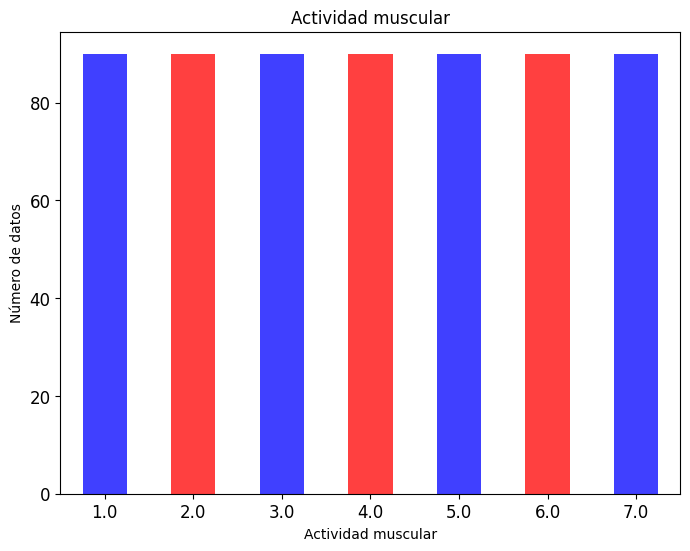

```python
# Determinamos el número de datos
act_muscular = df['act_muscular'].value_counts()
print(act_muscular)

# Gradica de barras
df['act_muscular'].value_counts().plot(kind='bar', color=['blue', 'red'], alpha=0.75, rot=0, figsize=(8, 6), fontsize=12)
# Añadimos título y etiquetas
plt.title('Actividad muscular')
plt.xlabel('Actividad muscular')
plt.ylabel('Número de datos')
plt.show()
```

No es necesario usar técnicas de balanceo sobre los datos

#### 2. Evalúa al menos 8 modelos de clasificación distintos utilizando validación cruzada, y determina cuál de ellos es el más efectivo.

```python
def evaluate_model_multiclass(model, X_train, y_train, X_test, y_test):
    pipeline = ImbPipeline(steps=[
        ('scaler', StandardScaler()),
        ('classifier', model)
    ])
    f1_scorer = make_scorer(f1_score, average='macro')

    # Validación cruzada en el conjunto de entrenamiento
    scores = cross_val_score(pipeline, X_train, y_train, cv=5, scoring=f1_scorer)
    print(f'F1 Score: {scores.mean():.4f}')

    # Ajuste del modelo
    pipeline.fit(X_train, y_train)
    y_pred = pipeline.predict(X_test)
    print(classification_report(y_test, y_pred))

    # Matriz de confusión para las 7 clases
    cm = confusion_matrix(y_test, y_pred)

    fig, ax = plt.subplots()
    im = ax.imshow(cm, interpolation='nearest', cmap=plt.cm.Blues)
    ax.figure.colorbar(im, ax=ax)
    # Mostramos las etiquetas

    ax.set(xticks=np.arange(cm.shape[1]),
              yticks=np.arange(cm.shape[0]),
              xticklabels=['Flexionar hacia arriba', 'Flexionar hacia abajo', 'Cerrar la mano', 'Estirar la mano', 'Abrir la mano', 'Coger un objeto', 'No moverse'], yticklabels=['Flexionar hacia arriba', 'Flexionar hacia abajo', 'Cerrar la mano', 'Estirar la mano', 'Abrir la mano', 'Coger un objeto', 'No moverse'],
              title='Matriz de confusión',
              ylabel='Etiqueta verdadera',
              xlabel='Etiqueta predicha')
    plt.setp(ax.get_xticklabels(), rotation=45, ha='right', rotation_mode='anchor')

    for i in range(cm.shape[0]):
        for j in range(cm.shape[1]):
            ax.text(j, i, format(cm[i, j], 'd'), ha='center', va='center', color='black')
    fig.tight_layout()
    plt.show()

    return scores.mean()
```

##### Separando df = Xtrain, Xtest. ytrain, ytest.

```python
X = df.drop(columns=['act_muscular'])
y = df['act_muscular']
X_train, X_test, y_train, y_test = train_test_split(X, y, test_size=0.4, random_state=42)
```

##### Regresión logística (Modelo lineal lógico)

```
-------- Regresión Logística --------
F1 Score: 0.8865
              precision    recall  f1-score   support

         1.0       0.91      0.93      0.92        44
         2.0       0.79      0.87      0.83        30
         3.0       0.88      0.95      0.91        38
         4.0       0.94      0.82      0.88        39
         5.0       0.84      0.94      0.89        33
         6.0       1.00      0.88      0.93        32
         7.0       0.91      0.86      0.89        36

    accuracy                           0.89       252
   macro avg       0.90      0.89      0.89       252
weighted avg       0.90      0.89      0.89       252
```

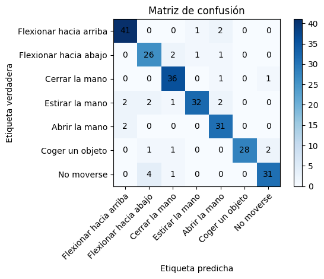

```
np.float64(0.8865485870798647)
```

```python
print('-------- Regresión Logística --------')
evaluate_model_multiclass(LogisticRegression(max_iter=1000), X_train, y_train, X_test, y_test)
```

##### Árbol de decisión (Modelo no-lineal lógico)

```
-------- Evaluando Árbol de Decisión --------
F1 Score: 0.6285
              precision    recall  f1-score   support

         1.0       0.83      0.57      0.68        44
         2.0       0.36      0.53      0.43        30
         3.0       0.74      0.82      0.78        38
         4.0       0.72      0.59      0.65        39
         5.0       0.54      0.67      0.59        33
         6.0       0.53      0.50      0.52        32
         7.0       0.91      0.81      0.85        36

    accuracy                           0.64       252
   macro avg       0.66      0.64      0.64       252
weighted avg       0.68      0.64      0.65       252
```

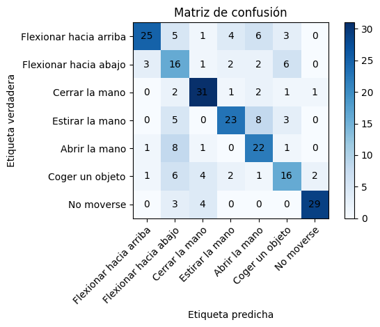

```
np.float64(0.6285252297809636)
```

```python
# Arbol de decisión
print('-------- Evaluando Árbol de Decisión --------')
evaluate_model_multiclass(DecisionTreeClassifier(), X_train, y_train, X_test, y_test)
```

##### Random Forest (Modelo no-lineal ensamble)

```
-------- Evaluando Random Forest --------
F1 Score: 0.8160
              precision    recall  f1-score   support

         1.0       0.95      0.80      0.86        44
         2.0       0.55      0.80      0.65        30
         3.0       0.87      0.87      0.87        38
         4.0       0.73      0.62      0.67        39
         5.0       0.72      0.94      0.82        33
         6.0       0.95      0.59      0.73        32
         7.0       0.92      0.94      0.93        36

    accuracy                           0.79       252
   macro avg       0.81      0.79      0.79       252
weighted avg       0.82      0.79      0.79       252
```

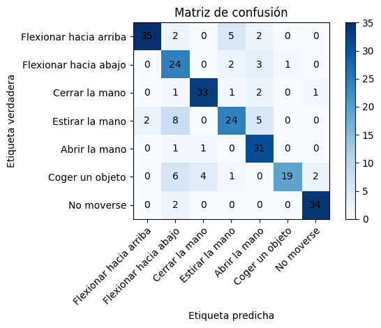

```
np.float64(0.8160245152100621)
```

```python
# Random Forest
print('-------- Evaluando Random Forest --------')
evaluate_model_multiclass(RandomForestClassifier(), X_train, y_train, X_test, y_test)
```

##### Support Vector Machine (Modelo no-lineal(kernel=rbf) geométrico)

```
-------- Evaluando SVM --------
F1 Score: 0.8830
              precision    recall  f1-score   support

         1.0       0.95      0.84      0.89        44
         2.0       0.65      0.73      0.69        30
         3.0       1.00      0.89      0.94        38
         4.0       0.75      0.69      0.72        39
         5.0       0.76      0.97      0.85        33
         6.0       1.00      0.84      0.92        32
         7.0       0.90      1.00      0.95        36

    accuracy                           0.85       252
   macro avg       0.86      0.85      0.85       252
weighted avg       0.86      0.85      0.85       252
```

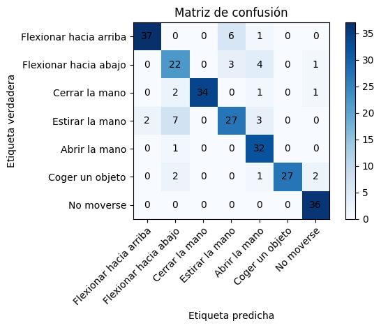

```
np.float64(0.882991002574719)
```

```python
# SVM
print('-------- Evaluando SVM --------')
evaluate_model_multiclass(SVC(kernel='rbf'), X_train, y_train, X_test, y_test)
```

##### Gradient Boosting (Modelo no-lineal ensamble)

```
-------- Evaluando Gradient Boosting --------
F1 Score: 0.8352
              precision    recall  f1-score   support

         1.0       0.87      0.75      0.80        44
         2.0       0.50      0.90      0.64        30
         3.0       0.76      0.92      0.83        38
         4.0       0.74      0.51      0.61        39
         5.0       0.85      0.85      0.85        33
         6.0       0.90      0.56      0.69        32
         7.0       0.91      0.86      0.89        36

    accuracy                           0.76       252
   macro avg       0.79      0.77      0.76       252
weighted avg       0.80      0.76      0.76       252
```

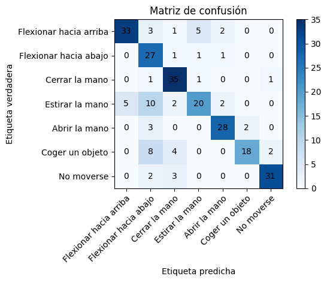

```
np.float64(0.8351788080199333)
```

```python
# Gradient Boosting
print('-------- Evaluando Gradient Boosting --------')
evaluate_model_multiclass(GradientBoostingClassifier(), X_train, y_train, X_test, y_test)
```

##### K-vecinos más cercanos (Modelo no-lineal geométrico)

```
-------- Evaluando KNN --------
```

[output not shown]

```
F1 Score: 0.7682
              precision    recall  f1-score   support

         1.0       0.87      0.77      0.82        44
         2.0       0.45      0.83      0.59        30
         3.0       0.91      0.84      0.88        38
         4.0       0.64      0.46      0.54        39
         5.0       0.88      0.88      0.88        33
         6.0       0.96      0.69      0.80        32
         7.0       0.92      1.00      0.96        36

    accuracy                           0.78       252
   macro avg       0.81      0.78      0.78       252
weighted avg       0.81      0.78      0.78       252
```

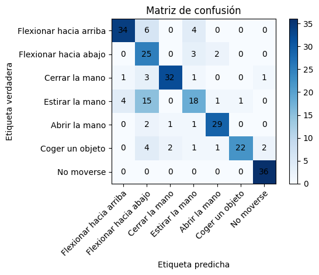

```
np.float64(0.7681926839108156)
```

```python
# KNN
print('-------- Evaluando KNN --------')
evaluate_model_multiclass(KNeighborsClassifier(), X_train, y_train, X_test, y_test)
```

##### Naive Bayes (Modelo lineal probabilistico)

```
-------- Evaluando Naive Bayes --------
F1 Score: 0.6418
              precision    recall  f1-score   support

         1.0       0.89      0.55      0.68        44
         2.0       0.27      0.60      0.37        30
         3.0       0.68      0.39      0.50        38
         4.0       0.31      0.33      0.32        39
         5.0       0.95      0.61      0.74        33
         6.0       0.48      0.50      0.49        32
         7.0       0.90      1.00      0.95        36

    accuracy                           0.56       252
   macro avg       0.64      0.57      0.58       252
weighted avg       0.65      0.56      0.58       252
```

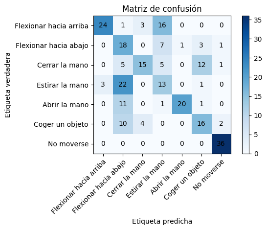

```
np.float64(0.6418202709310723)
```

```python
# Naive Bayes
print('-------- Evaluando Naive Bayes --------')
evaluate_model_multiclass(GaussianNB(), X_train, y_train, X_test, y_test)
```

#### 3. Escoge al menos dos clasificadores que hayas evaluado en el paso anterior e identifica sus hiperparámetros. Lleva a cabo el proceso de validación cruzada anidada para evaluar los dos modelos con la selección óptima de hiperparámetros.

```python
# submuestreo, validación cruzada y selección de características
def evaluate_model_fs2(model, X_train, y_train, X_test, y_test, feature_selector_method, param_values=None):
    # Definir la validación cruzada externa
    outer_kf = KFold(n_splits=5, shuffle=True, random_state=0)
    fold_scores = []
    f1_scores = []
    f2_scores = []
    f3_scores = []
    f4_scores = []
    f5_scores = []
    f6_scores = []
    f7_scores = []


    for outer_train_index, outer_test_index in outer_kf.split(X):
        print(f'Partición {len(fold_scores) + 1} de {outer_kf.get_n_splits()}')

        # Si X es un DataFrame
        X_train, X_test = X.iloc[outer_train_index], X.iloc[outer_test_index]
        y_train, y_test = y.iloc[outer_train_index], y.iloc[outer_test_index]

        # Definir la validación cruzada interna
        inner_kf = KFold(n_splits=5, shuffle=True, random_state=0)

        f1_scorer = make_scorer(f1_score, average='macro')

        # Selección de características basada en el método proporcionado
        if feature_selector_method == 'filter':
            feature_selector = SelectKBest(f_classif)
        elif feature_selector_method == 'wrapper':
            feature_selector = RFE(estimator=RandomForestClassifier())
        elif feature_selector_method == 'recursivo':
            feature_selector = RFECV(estimator=RandomForestClassifier(), step=1, cv=inner_kf, scoring=f1_scorer)
        else:
            raise ValueError(f"Método de selección de características '{feature_selector_method}' no reconocido")

        # Crear el pipeline con selección de características y clasificación
        pipeline = ImbPipeline(steps=[
            ('scaler', StandardScaler()),
            ('feature_selection', feature_selector),
            ('classifier', model)
        ])


        # Configurar la búsqueda de hiperparámetros en la validación cruzada interna
        grid_search = GridSearchCV(pipeline, param_values, cv=inner_kf, scoring=f1_scorer, n_jobs=-1)

        # Ajustar la búsqueda de hiperparámetros
        grid_search.fit(X_train, y_train)

        # Obtener el mejor pipeline con los hiperparámetros óptimos
        best_pipeline = grid_search.best_estimator_

        # Evaluar el mejor pipeline en el conjunto de prueba interno
        y_pred = best_pipeline.predict(X_test)

        f1 = classification_report(y_test, y_pred, output_dict=True)
        fold_scores.append(f1)
        print(f1)



        # Imprimir características seleccionadas
        feature_selector = best_pipeline.named_steps['feature_selection']
        selected_features = X_train.columns[feature_selector.get_support()]

        if feature_selector_method == 'filter':
            print(f'\nParticion numero {len(fold_scores)}: Características seleccionadas (Filtro): {selected_features}')
        elif feature_selector_method == 'wrapper':
            print(f'\nPaticion numero {len(fold_scores)}: Características seleccionadas (Wrapper): {selected_features}')
        elif feature_selector_method == 'recursivo':
            print(f'\nPaticion numero {len(fold_scores)}: Características seleccionadas (Recursivo): {selected_features}')

        for key, values in f1.items():
            if key == '1.0':
                print(f'f-score para la clase 1 {values["f1-score"]}')
                f1_scores.append(values["f1-score"])
            elif key == '2.0':
                print(f'f-score para la clase 2 {values["f1-score"]}')
                f2_scores.append(values["f1-score"])
            elif key == '3.0':
                print(f'f-score para la clase 3 {values["f1-score"]}')
                f3_scores.append(values["f1-score"])
            elif key == '4.0':
                print(f'f-score para la clase 4 {values["f1-score"]}')
                f4_scores.append(values["f1-score"])
            elif key == '5.0':
                print(f'f-score para la clase 5 {values["f1-score"]}')
                f5_scores.append(values["f1-score"])
            elif key == '6.0':
                print(f'f-score para la clase 6 {values["f1-score"]}')
                f6_scores.append(values["f1-score"])
            elif key == '7.0':
                print(f'f-score para la clase 7 {values["f1-score"]}')
                f7_scores.append(values["f1-score"])


        #pprint(f1)
    print (f'\n\tf1-score promedio para la clase 1: {np.mean(f1_scores)}')
    print (f'\n\tf1-score promedio para la clase 2: {np.mean(f2_scores)}')
    print (f'\n\tf1-score promedio para la clase 3: {np.mean(f3_scores)}')
    print (f'\n\tf1-score promedio para la clase 4: {np.mean(f4_scores)}')
    print (f'\n\tf1-score promedio para la clase 5: {np.mean(f5_scores)}')
    print (f'\n\tf1-score promedio para la clase 6: {np.mean(f6_scores)}')
    print (f'\n\tf1-score promedio para la clase 7: {np.mean(f7_scores)}')
```

```python
# Random Forest
print('-------- Evaluando Random Forest --------')
evaluate_model_fs2(RandomForestClassifier(), X_train, y_train, X_test, y_test, 'recursivo', param_values={'feature_selection__step': [40, 60, 80, 100],
                                                                                                        'classifier__n_estimators': [10, 50, 100]})
```

```
-------- Evaluando Random Forest --------
Partición 1 de 5
{'1.0': {'precision': 0.9545454545454546, 'recall': 0.9130434782608695, 'f1-score': 0.9333333333333333, 'support': 23.0}, '2.0': {'precision': 0.6470588235294118, 'recall': 0.8461538461538461, 'f1-score': 0.7333333333333333, 'support': 13.0}, '3.0': {'precision': 0.8636363636363636, 'recall': 0.8260…

Paticion numero 1: Características seleccionadas (Recursivo): Index([  2,   3,   4,   5,   6,   8,   9,  10,  11,  12,
       ...
       618, 619, 620, 622, 624, 626, 627, 628, 629, 630],
      dtype='object', length=430)
f-score para la clase 1 0.9333333333333333
f-score para la clase 2 0.7333333333333333
f-score para la clase 3 0.8444444444444444
f-score para la clase 4 0.7407407407407407
f-score para la clase 5 0.8780487804878049
f-score para la clase 6 0.8837209302325582
f-score para la clase 7 0.8571428571428571
Partición 2 de 5
{'1.0': {'precision': 0.7692307692307693, 'recall': 0.7692307692307693, 'f1-score': 0.7692307692307693, 'support': 13.0}, '2.0': {'precision': 0.8333333333333334, 'recall': 0.5263157894736842, 'f1-score': 0.6451612903225806, 'support': 19.0}, '3.0': {'precision': 0.8125, 'recall': 0.8666666666666667…

Paticion numero 2: Características seleccionadas (Recursivo): Index([  2,   3,   4,   5,   8,   9,  11,  12,  14,  15,
       ...
       617, 618, 619, 620, 622, 624, 626, 627, 628, 630],
      dtype='object', length=310)
f-score para la clase 1 0.7692307692307693
f-score para la clase 2 0.6451612903225806
f-score para la clase 3 0.8387096774193549
f-score para la clase 4 0.782608695652174
f-score para la clase 5 0.8888888888888888
f-score para la clase 6 0.8205128205128205
f-score para la clase 7 0.9615384615384616
Partición 3 de 5
{'1.0': {'precision': 0.9375, 'recall': 0.8823529411764706, 'f1-score': 0.9090909090909091, 'support': 17.0}, '2.0': {'precision': 0.6666666666666666, 'recall': 0.7619047619047619, 'f1-score': 0.7111111111111111, 'support': 21.0}, '3.0': {'precision': 0.9090909090909091, 'recall': 0.7692307692307693…

Paticion numero 3: Características seleccionadas (Recursivo): Index([  2,   3,   4,   5,   7,   8,  10,  11,  12,  14,
       ...
       619, 620, 622, 624, 625, 626, 627, 628, 630, 631],
      dtype='object', length=430)
f-score para la clase 1 0.9090909090909091
f-score para la clase 2 0.7111111111111111
f-score para la clase 3 0.8333333333333334
f-score para la clase 4 0.9047619047619048
```

[output cut: 30 more lines]

[output not shown]

```python
# SVC
print('-------- Evaluando SVM --------')
evaluate_model_fs2(SVC(kernel='rbf'), X_train, y_train, X_test, y_test, 'recursivo', param_values={'feature_selection__step': [5, 10, 40, 50],
                                                                                                    'classifier__C': [0.1, 1, 10],
                                                                                                    'classifier__gamma': [0.001, 0.01, 0.1, 1, 10]})
```

```
-------- Evaluando SVM --------
Partición 1 de 5
```

[output not shown]

[output cut: 96 more lines]

```python
print('-------- Evaluando DT --------')
evaluate_model_fs2(DecisionTreeClassifier(), X_train, y_train, X_test, y_test, 'wrapper', param_values={'feature_selection__n_features_to_select': [400, 500, 600],
                                                                                                        'classifier__ccp_alpha': [0.0, 0.1, 0.2]})
```

```
-------- Evaluando DT --------
Partición 1 de 5
{'1.0': {'precision': 0.9130434782608695, 'recall': 0.9130434782608695, 'f1-score': 0.9130434782608695, 'support': 23.0}, '2.0': {'precision': 0.3888888888888889, 'recall': 0.5384615384615384, 'f1-score': 0.45161290322580644, 'support': 13.0}, '3.0': {'precision': 0.76, 'recall': 0.8260869565217391,…

Paticion numero 1: Características seleccionadas (Wrapper): Index([  2,   3,   4,   5,   8,  11,  14,  15,  16,  17,
       ...
       621, 622, 624, 625, 626, 627, 628, 629, 630, 631],
      dtype='object', length=400)
f-score para la clase 1 0.9130434782608695
f-score para la clase 2 0.45161290322580644
f-score para la clase 3 0.7916666666666666
f-score para la clase 4 0.2608695652173913
f-score para la clase 5 0.7368421052631579
f-score para la clase 6 0.5957446808510638
f-score para la clase 7 0.7368421052631579
Partición 2 de 5
{'1.0': {'precision': 0.55, 'recall': 0.8461538461538461, 'f1-score': 0.6666666666666666, 'support': 13.0}, '2.0': {'precision': 0.7692307692307693, 'recall': 0.5263157894736842, 'f1-score': 0.625, 'support': 19.0}, '3.0': {'precision': 0.6190476190476191, 'recall': 0.8666666666666667, 'f1-score': 0…

Paticion numero 2: Características seleccionadas (Wrapper): Index([  2,   3,   4,   5,   6,   7,   8,   9,  10,  11,
       ...
       622, 623, 624, 625, 626, 627, 628, 629, 630, 631],
      dtype='object', length=500)
f-score para la clase 1 0.6666666666666666
f-score para la clase 2 0.625
f-score para la clase 3 0.7222222222222222
f-score para la clase 4 0.5555555555555556
f-score para la clase 5 0.7096774193548387
f-score para la clase 6 0.5142857142857142
f-score para la clase 7 0.8979591836734694
Partición 3 de 5
{'1.0': {'precision': 1.0, 'recall': 0.6470588235294118, 'f1-score': 0.7857142857142857, 'support': 17.0}, '2.0': {'precision': 0.46153846153846156, 'recall': 0.5714285714285714, 'f1-score': 0.5106382978723404, 'support': 21.0}, '3.0': {'precision': 0.8333333333333334, 'recall': 0.7692307692307693, …

Paticion numero 3: Características seleccionadas (Wrapper): Index([  2,   3,   4,   5,   6,   8,   9,  10,  11,  12,
       ...
       621, 622, 623, 624, 625, 626, 627, 628, 629, 630],
      dtype='object', length=400)
f-score para la clase 1 0.7857142857142857
f-score para la clase 2 0.5106382978723404
f-score para la clase 3 0.8
f-score para la clase 4 0.6666666666666666
```

[output cut: 30 more lines]

```
f-score para la clase 7 0.8333333333333334

	f1-score promedio para la clase 1: 0.7778910876787519

	f1-score promedio para la clase 2: 0.550539941216307

	f1-score promedio para la clase 3: 0.7372060522060523

	f1-score promedio para la clase 4: 0.5283029453015426

	f1-score promedio para la clase 5: 0.665061480681175

	f1-score promedio para la clase 6: 0.554538018632466

	f1-score promedio para la clase 7: 0.8348033950422273
```

#### 4. Prepara tus modelos para producción haciendo lo siguiente:

##### A. Opten los hiperparámetros óptimos utilizando todo el conjunto de datos con validación cruzada.

```python
# submuestreo, validación cruzada y selección de características
def eval_model2(model, X, y, feature_selector_method, param_values=None):
    # Definir la validación cruzada externa
    outer_kf = KFold(n_splits=5, shuffle=True, random_state=0)
    fold_scores = []
    f1_scores = []
    f2_scores = []
    f3_scores = []
    f4_scores = []
    f5_scores = []
    f6_scores = []
    f7_scores = []


    for outer_train_index, outer_test_index in outer_kf.split(X):
        print(f'Partición {len(fold_scores) + 1} de {outer_kf.get_n_splits()}')

        # Si X es un DataFrame
        X_train, X_test = X.iloc[outer_train_index], X.iloc[outer_test_index]
        y_train, y_test = y.iloc[outer_train_index], y.iloc[outer_test_index]

        # Definir la validación cruzada interna
        inner_kf = KFold(n_splits=5, shuffle=True, random_state=0)

        f1_scorer = make_scorer(f1_score, average='macro')

        # Selección de características basada en el método proporcionado
        if feature_selector_method == 'filter':
            feature_selector = SelectKBest(f_classif)
        elif feature_selector_method == 'wrapper':
            feature_selector = RFE(estimator=RandomForestClassifier())
        elif feature_selector_method == 'recursivo':
            feature_selector = RFECV(estimator=RandomForestClassifier(), step=1, cv=inner_kf, scoring=f1_scorer)
        else:
            raise ValueError(f"Método de selección de características '{feature_selector_method}' no reconocido")

        # Crear el pipeline con selección de características y clasificación
        pipeline = ImbPipeline(steps=[
            ('scaler', StandardScaler()),
            ('feature_selection', feature_selector),
            ('classifier', model)
        ])


        # Configurar la búsqueda de hiperparámetros en la validación cruzada interna
        grid_search = GridSearchCV(pipeline, param_values, cv=inner_kf, scoring=f1_scorer, n_jobs=-1)

        # Ajustar la búsqueda de hiperparámetros
        grid_search.fit(X_train, y_train)

        # Obtener el mejor pipeline con los hiperparámetros óptimos
        best_pipeline = grid_search.best_estimator_

        # Evaluar el mejor pipeline en el conjunto de prueba interno
        y_pred = best_pipeline.predict(X_test)

        f1 = classification_report(y_test, y_pred, output_dict=True)
        fold_scores.append(f1)
        print(f1)



        # Imprimir características seleccionadas
        feature_selector = best_pipeline.named_steps['feature_selection']
        selected_features = X_train.columns[feature_selector.get_support()]

        if feature_selector_method == 'filter':
            print(f'\nParticion numero {len(fold_scores)}: Características seleccionadas (Filtro): {selected_features}')
        elif feature_selector_method == 'wrapper':
            print(f'\nPaticion numero {len(fold_scores)}: Características seleccionadas (Wrapper): {selected_features}')
        elif feature_selector_method == 'recursivo':
            print(f'\nPaticion numero {len(fold_scores)}: Características seleccionadas (Recursivo): {selected_features}')

        for key, values in f1.items():
            if key == '1.0':
                print(f'f-score para la clase 1 {values["f1-score"]}')
                f1_scores.append(values["f1-score"])
            elif key == '2.0':
                print(f'f-score para la clase 2 {values["f1-score"]}')
                f2_scores.append(values["f1-score"])
            elif key == '3.0':
                print(f'f-score para la clase 3 {values["f1-score"]}')
                f3_scores.append(values["f1-score"])
            elif key == '4.0':
                print(f'f-score para la clase 4 {values["f1-score"]}')
                f4_scores.append(values["f1-score"])
            elif key == '5.0':
                print(f'f-score para la clase 5 {values["f1-score"]}')
                f5_scores.append(values["f1-score"])
            elif key == '6.0':
                print(f'f-score para la clase 6 {values["f1-score"]}')
                f6_scores.append(values["f1-score"])
            elif key == '7.0':
                print(f'f-score para la clase 7 {values["f1-score"]}')
                f7_scores.append(values["f1-score"])


        #pprint(f1)
    print (f'\n\tf1-score promedio para la clase 1: {np.mean(f1_scores)}')
    print (f'\n\tf1-score promedio para la clase 2: {np.mean(f2_scores)}')
    print (f'\n\tf1-score promedio para la clase 3: {np.mean(f3_scores)}')
    print (f'\n\tf1-score promedio para la clase 4: {np.mean(f4_scores)}')
    print (f'\n\tf1-score promedio para la clase 5: {np.mean(f5_scores)}')
    print (f'\n\tf1-score promedio para la clase 6: {np.mean(f6_scores)}')
    print (f'\n\tf1-score promedio para la clase 7: {np.mean(f7_scores)}')
    return best_pipeline
```

```python
model = eval_model2(RandomForestClassifier(), X, y, 'recursivo', param_values={'feature_selection__step': [40, 60, 80, 100],
                                                                               'classifier__n_estimators': [10, 50, 100]})
```

```
Partición 1 de 5
{'1.0': {'precision': 0.9545454545454546, 'recall': 0.9130434782608695, 'f1-score': 0.9333333333333333, 'support': 23.0}, '2.0': {'precision': 0.6111111111111112, 'recall': 0.8461538461538461, 'f1-score': 0.7096774193548387, 'support': 13.0}, '3.0': {'precision': 0.8181818181818182, 'recall': 0.7826…

Paticion numero 1: Características seleccionadas (Recursivo): Index([  2,   3,   4,   5,   6,   7,   8,   9,  10,  11,
       ...
       622, 623, 624, 625, 626, 627, 628, 629, 630, 631],
      dtype='object', length=530)
f-score para la clase 1 0.9333333333333333
f-score para la clase 2 0.7096774193548387
f-score para la clase 3 0.8
f-score para la clase 4 0.6896551724137931
f-score para la clase 5 0.9047619047619048
f-score para la clase 6 0.8205128205128205
f-score para la clase 7 0.8571428571428571
Partición 2 de 5
{'1.0': {'precision': 0.8125, 'recall': 1.0, 'f1-score': 0.896551724137931, 'support': 13.0}, '2.0': {'precision': 0.9230769230769231, 'recall': 0.631578947368421, 'f1-score': 0.75, 'support': 19.0}, '3.0': {'precision': 0.8571428571428571, 'recall': 0.8, 'f1-score': 0.8275862068965517, 'support': 1…

Paticion numero 2: Características seleccionadas (Recursivo): Index([  2,   3,   5,   6,   8,  11,  14,  15,  17,  20,
       ...
       613, 614, 618, 619, 620, 622, 624, 626, 628, 630],
      dtype='object', length=230)
f-score para la clase 1 0.896551724137931
f-score para la clase 2 0.75
f-score para la clase 3 0.8275862068965517
f-score para la clase 4 0.8181818181818182
f-score para la clase 5 0.9629629629629629
f-score para la clase 6 0.8717948717948718
f-score para la clase 7 0.9615384615384616
Partición 3 de 5
{'1.0': {'precision': 1.0, 'recall': 0.8823529411764706, 'f1-score': 0.9375, 'support': 17.0}, '2.0': {'precision': 0.6666666666666666, 'recall': 0.7619047619047619, 'f1-score': 0.7111111111111111, 'support': 21.0}, '3.0': {'precision': 1.0, 'recall': 0.6923076923076923, 'f1-score': 0.81818181818181…

Paticion numero 3: Características seleccionadas (Recursivo): Index([  2,   3,   4,   5,   6,   7,   8,  10,  11,  12,
       ...
       619, 620, 621, 622, 623, 624, 626, 628, 629, 630],
      dtype='object', length=430)
f-score para la clase 1 0.9375
f-score para la clase 2 0.7111111111111111
f-score para la clase 3 0.8181818181818182
f-score para la clase 4 0.8372093023255814
f-score para la clase 5 0.8648648648648649
```

[output cut: 29 more lines]

```
f-score para la clase 7 0.9047619047619048

	f1-score promedio para la clase 1: 0.9117657815477287

	f1-score promedio para la clase 2: 0.7296532015886854

	f1-score promedio para la clase 3: 0.832605985968055

	f1-score promedio para la clase 4: 0.8021657572579788

	f1-score promedio para la clase 5: 0.8877877877877879

	f1-score promedio para la clase 6: 0.8279679130937712

	f1-score promedio para la clase 7: 0.9125249019985862
```

```python
model.fit(X,y)
```

```
Pipeline(steps=[('scaler', StandardScaler()),
                ('feature_selection',
                 RFECV(cv=KFold(n_splits=5, random_state=0, shuffle=True),
                       estimator=RandomForestClassifier(),
                       scoring=make_scorer(f1_score, response_method='predict', average=macro),
                       step=80)),
                ('classifier', RandomForestClassifier(n_estimators=50))])
```

```python
print(model.named_steps['classifier'].feature_importances_)
```

[output not shown]

[output cut: 24 more lines]

[output not shown]

```python
print(model.named_steps['feature_selection'].get_support())
```

[output not shown]

#### 5.Contesta lo siguientes:

##### A. ¿Observas un problema en cuanto al balanceo de las clases? ¿Por qué?

No se necesita hacer balanceo de las clases

##### D.¿Qué inconvenientes hay al encontrar hiperparámetros? ¿Por qué?

El costo más notable al entrenar el modelo es el costo computacional, se requiere muchos recursos para poder encontrar el número óptimo de hiperparámetros si se seleccionan muchos de estos y si son aleatoreos.

También podría causar un overfitting ya que se podrían ajustar a los datos en validación, sin embargo, se podría evitar con un subconjunto de los datos.